# FinRisk check-in

Available at lcgodoy.me/slides/2025-frcheck/

Lucas da C. Godoy

ldcgodoy@ucsc.com

EEB Department, UCSC

Mark Morales

mamamora@ucsc.com

EEB Department, UCSC

Malin Pinsky

mpinsky@ucsc.com

EEB Department, UCSC

2025-05-21

## `drmr` package

- DRMs explicitly incorporate demographic processes that drive range dynamics (Pagel and Schurr 2012). They allow for linking environmental drivers directly to specific processes and have the potential for more robust forecasting under novel conditions.
- `drmr` goal: Bridge the gap between DRM potential and practical application.
- Check out [online](https://pinskylab.github.io/drmr/).

## Spoiler: Comparison to an SDM

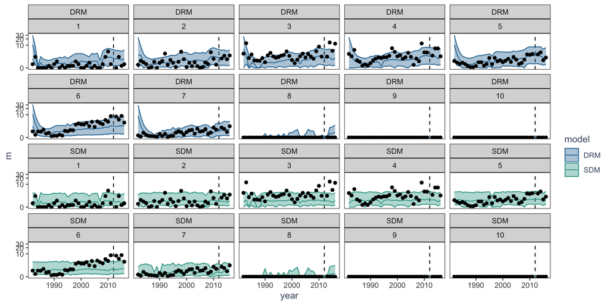

## More spoilers

| Species | Model | RMSE | IS (80%) |
| --- | --- | --- | --- |
| Summer flounder | DRM | 9.49 | 7.83 |
|  | SDM | 13.20 | 11.80 |
| Red-bellied woodpecker | DRM | 4.49 | 8.68 |
|  | SDM | 6.86 | 6.20 |

## What about *FinRisk*?

- Key Environmental Drivers: NEA Mackerel distribution is primarily driven by SST, prey availability, and stock size. Mackerel density peaks around $8.5$ to $12^\circ$ (Ono et al. 2024) with no ocurrences registered when temperature is below $4.8^\circ$ (Olafsdottir et al. 2019)
- Data Availability: Data available from various surveys (Egg Survey for spawning/SSB; Bottom Trawl for juveniles). No single survey offers complete coverage of all life stages or the entire distribution annually.
- IESSNS: The International Ecosystem Summer Survey in the Nordic Seas (IESSNS) is likely the most appropriate for adult summer feeding distribution, providing annual, age-disaggregated abundance indices and tracking distribution.

## More about data availability

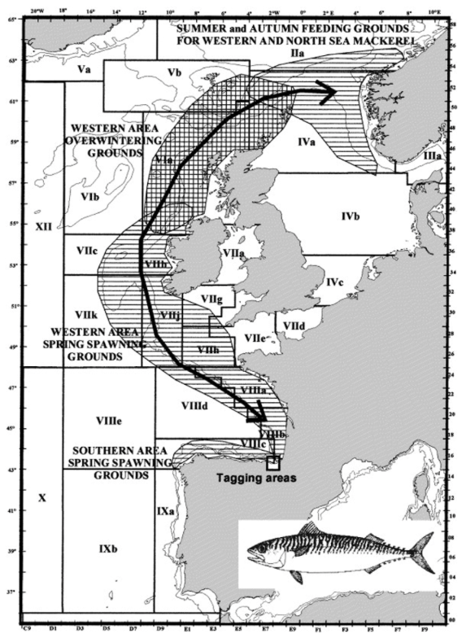

| Survey | Distribution | Start | Age structure |
| --- | --- | --- | --- |
| IESSNS | Summer feeding | 2010 | Age and size composition (Age 3+) |
| BTS | Overwinter | 1965 | Age-0 abundance index |
| Egg Survey | Spawning | 1992 | No age structure |

## What’s next?

- Preliminary results for FinRisk September meeting
- Taylor the package code to the NEA species
- Simulation based inference: Neural Bayes Estimators (Sainsbury-Dale et al. 2024)
- Coordinate how (and what) the results would be more useful for the translational tools and the financial risk analyses —

### References

Olafsdottir, A. H., Utne, K. R., Jacobsen, J. A., Jansen, T., Óskarsson, GuJ., Nøttestad, L., Elvarsson, B., Broms, C., and Slotte, A. (2019), “Geographical expansion of Northeast Atlantic mackerel (Scomber scombrus) in the Nordic Seas from 2007 to 2016 was primarily driven by stock size and constrained by low temperatures,” *Deep Sea Research Part II: Topical Studies in Oceanography*, 159, 152–168. https://doi.org/10.1016/j.dsr2.2018.05.023.

Ono, K., Katara, I., Eliasen, S. K., Broms, C., Campbell, A., Santos Schmidt, T. C. dos, Egan, A., Hølleland, S. N., Jacobsen, J. A., Jansen, T., Mackinson, S., Mousing, E. A., Nash, R. D. M., Nikolioudakis, N., Nnanatu, C., Nøttestad, L., Singh, W., Slotte, A., Wieland, K., and Olafsdottir, A. H. (2024), “Effect of environmental drivers on the spatiotemporal distribution of mackerel at age in the Nordic Seas during 2010-20,” *ICES Journal of Marine Science*, 81, 1282–1294. https://doi.org/10.1093/icesjms/fsae087.

Pagel, J., and Schurr, F. M. (2012), “Forecasting species ranges by statistical estimation of ecological niches and spatial population dynamics,” *Global Ecology and Biogeography*, 21, 293–304. https://doi.org/https://doi.org/10.1111/j.1466-8238.2011.00663.x.

Sainsbury-Dale, M., Zammit-Mangion, A., and and, R. H. (2024), “Likelihood-free parameter estimation with neural bayes estimators,” *The American Statistician*, ASA Website, 78, 1–14. https://doi.org/10.1080/00031305.2023.2249522.